# Energy Data Analysis

Ashish

13/10/2020

## Prerequisites

```r
# load package
library(ggplot2)
library(tidyverse)
#library(ggpubr)
#library(reshape2)
#library(MASS)
```

```r
#dir=getwd()
#dir
#setwd(dir)
```

## Read Data

```r
# read salary data and saved it in dat
dat <- read.csv("eng-data.csv", header=TRUE, sep = ",")
head(dat)
```

```
##         Date Consumption Wind Solar Wind.Solar
## 1 2006-01-01    1069.184   NA    NA         NA
## 2 2006-01-02    1380.521   NA    NA         NA
## 3 2006-01-03    1442.533   NA    NA         NA
## 4 2006-01-04    1457.217   NA    NA         NA
## 5 2006-01-05    1477.131   NA    NA         NA
## 6 2006-01-06    1403.427   NA    NA         NA
```

## Check data types

```r
## Convert date to Date Data Type
dat$Date <- as.Date(dat$Date)

str(dat)
```

```
## 'data.frame':    4383 obs. of  5 variables:
##  $ Date       : Date, format: "2006-01-01" "2006-01-02" ...
##  $ Consumption: num  1069 1381 1443 1457 1477 ...
##  $ Wind       : num  NA NA NA NA NA NA NA NA NA NA ...
##  $ Solar      : num  NA NA NA NA NA NA NA NA NA NA ...
##  $ Wind.Solar : num  NA NA NA NA NA NA NA NA NA NA ...
```

#CHECK DIMENSION OF DATASET

```r
dim(dat)
```

```
## [1] 4383    5
```

## CHECK MISSING VALUE

```r
any(is.na(dat))
```

```
## [1] TRUE
```

```r
sapply(dat, function(x) sum(is.na(x)))
```

```
##        Date Consumption        Wind       Solar  Wind.Solar
##           0           0        1463        2195        2196
```

# Remove missing values

```r
dat <- na.omit(dat)
any(is.na(dat))
```

```
## [1] FALSE
```

## Summary statistics

```r
summary(dat)
```

```
##       Date             Consumption          Wind             Solar
##  Min.   :2012-01-01   Min.   : 899.8   Min.   :  6.511   Min.   :  1.968
##  1st Qu.:2013-07-02   1st Qu.:1222.0   1st Qu.: 72.367   1st Qu.: 35.161
##  Median :2015-01-03   Median :1380.2   Median :136.842   Median : 86.390
##  Mean   :2015-01-01   Mean   :1347.5   Mean   :183.432   Mean   : 89.232
##  3rd Qu.:2016-07-02   3rd Qu.:1460.1   3rd Qu.:245.028   3rd Qu.:135.038
##  Max.   :2017-12-31   Max.   :1682.0   Max.   :826.278   Max.   :241.580
##    Wind.Solar
##  Min.   : 21.48
##  1st Qu.:172.19
##  Median :240.99
##  Mean   :272.66
##  3rd Qu.:338.99
##  Max.   :851.56
```

## Plot Date Vs (Consumption, Wind and Solar)

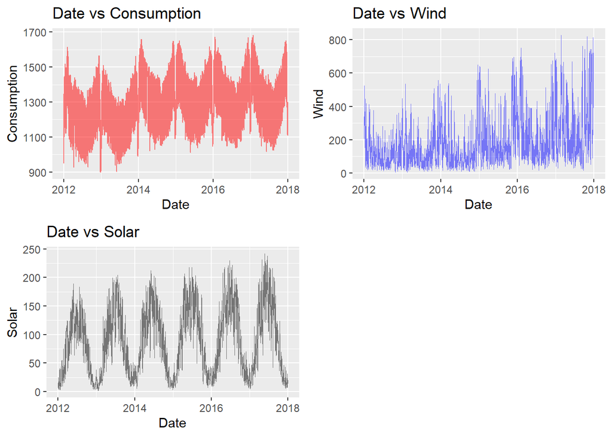

```r
library(ggpubr)
p1 <- ggplot(dat, aes(x =Date, y =Consumption)) + geom_line(alpha=0.5, size=0.5, color="red") + labs(title="Date vs Consumption")
p2 <- ggplot(dat, aes(x =Date, y =Wind)) + geom_line(alpha=0.5, size=0.3, color="blue") + labs(title="Date vs Wind")
p3 <- ggplot(dat, aes(x =Date, y =Solar)) + geom_line(alpha=0.5, size=0.3) + labs(title="Date vs Solar")
ggarrange(p1, p2, p3, ncol = 2, nrow = 2)
```

## Lets investigate a single year to have a closer look. ## Add a new Date column into an existing data frame and split it

```r
# apply separate function to split x into Year", "Month", "Day
x <- dat$Date
dat$date_x <- as.Date(x)

# apply separate function to split x into Year", "Month", "Day
dat_2 <- separate(dat, date_x, c("Year", "Month", "Day"), sep = '-')
head(dat_2)
```

```
##            Date Consumption    Wind  Solar Wind.Solar Year Month Day
## 2192 2012-01-01     948.128 227.465  6.587    234.052 2012    01  01
## 2193 2012-01-02    1269.581 207.327  6.574    213.901 2012    01  02
## 2194 2012-01-03    1334.745 473.468 24.679    498.147 2012    01  03
## 2195 2012-01-04    1347.136 499.804 14.681    514.485 2012    01  04
## 2196 2012-01-05    1376.658 523.851  5.071    528.922 2012    01  05
## 2197 2012-01-06    1291.215 286.265 13.160    299.425 2012    01  06
```

## Change date items (year, month, date) seperated into numeric

```r
## Save data for group by Analysis
dat_3 <- dat_2

dat_2$Year  <- as.numeric(dat_2$Year)
dat_2$Month <- as.numeric(dat_2$Month)
dat_2$Day   <- as.numeric(dat_2$Day)
head(dat_2)
```

```
##            Date Consumption    Wind  Solar Wind.Solar Year Month Day
## 2192 2012-01-01     948.128 227.465  6.587    234.052 2012     1   1
## 2193 2012-01-02    1269.581 207.327  6.574    213.901 2012     1   2
## 2194 2012-01-03    1334.745 473.468 24.679    498.147 2012     1   3
## 2195 2012-01-04    1347.136 499.804 14.681    514.485 2012     1   4
## 2196 2012-01-05    1376.658 523.851  5.071    528.922 2012     1   5
## 2197 2012-01-06    1291.215 286.265 13.160    299.425 2012     1   6
```

## Plot Consumption vs a Year, say 2016

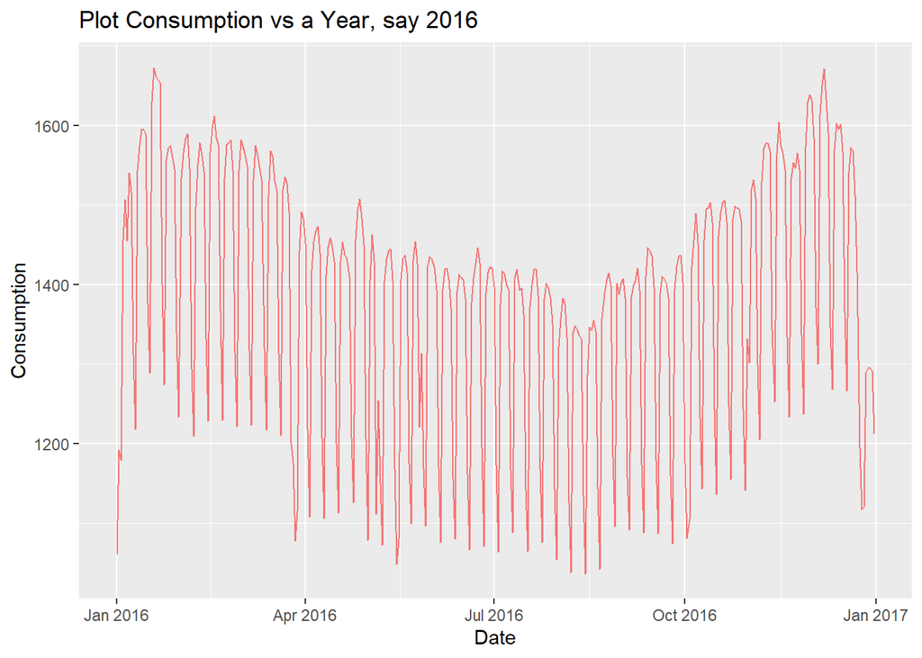

```r
# filter data for Year 2016
dy <- filter(dat_2, dat_2$Year == 2016)
ggplot(dy, aes(x=Date, y=Consumption)) + geom_line(alpha=0.5, size=0.5, color="red") + labs(title="Plot Consumption vs a Year, say 2016")
```

####From the above figure we can clearly see the consumption of electricity for Year 2016. There is a drastic decrease in the consumption of electricity at the end of the year (December) and during August.

#Lets investigate December month in 2016 ##Plot Consumption for December month 2016

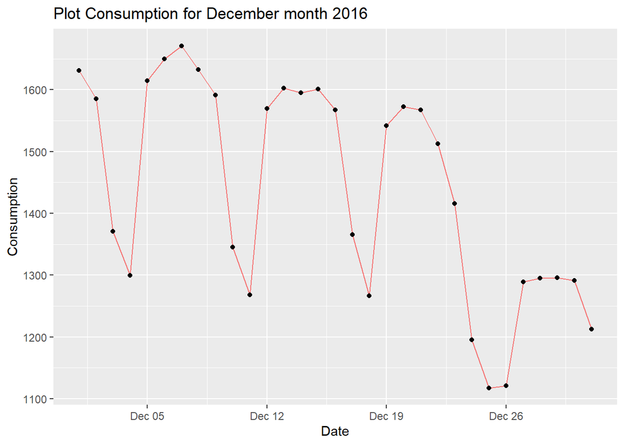

```r
# filter data for month December and Year 2016
dy <- filter(dat_2, dat_2$Year == 2016 & Month == 12)
ggplot(dy, aes(x=Date , y=Consumption)) + geom_line(alpha=0.5, size=0.5, color="red") + geom_point()+ labs(title="Plot Consumption for December month 2016")
```

####As shown in the above figure, electricity consumption is higher on weekdays and lowest at the weekends. We can also investigate the consumption for each day of the month.

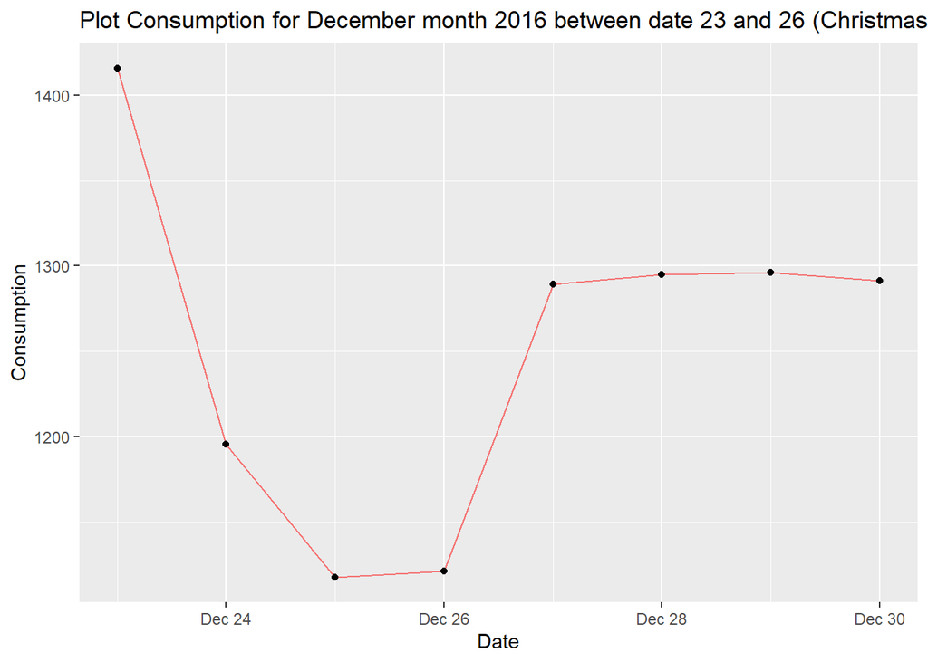

```r
# filter data for last week of December 2016
dy <- filter(dat_2, dat_2$Year == 2016 & Month == 12 & Day >=23 & Day <=30)
ggplot(dy, aes(x=Date , y=Consumption)) + geom_line(alpha=0.5, size=0.5, color="red") + geom_point()+ labs(title="Plot Consumption for December month 2016 between date 23 and 26 (Christmas Time)")
```

#### From the above fiure, we can see that electricity consumption was lowest on the day of Christmas, probably because people were busy partying. After Christmas, the consumption increased.

## Grouping time series data We can group the data by different time periods and present them in box plot.

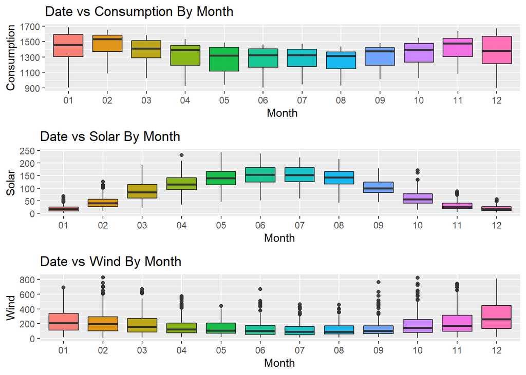

```r
### Plot data by months. Use the box plots to visualise the data vs month
pa1 <- ggplot(data=dat_3, mapping=aes(x=Month, y=Consumption, fill=Month)) + geom_boxplot(alpha=0.9) + theme(legend.position="none") + labs(title="Date vs Consumption By Month")

pa2 <- ggplot(data=dat_3, mapping=aes(x=Month, y=Solar, fill=Month)) + geom_boxplot(alpha=0.9)+ theme(legend.position="none") + labs(title="Date vs Solar By Month")

pa3 <- ggplot(data=dat_3, mapping=aes(x=Month, y=Wind, fill=Month)) + geom_boxplot(alpha=0.9)+ theme(legend.position="none") + labs(title="Date vs Wind By Month")

ggarrange(pa1, pa2, pa3 , ncol = 1, nrow = 3) #labels = c("Consumption", "Wind", "Solar")
```

#Lets investigate consumption of electricity by the day of the week

##Convert Date into Weekday using weekdays Function

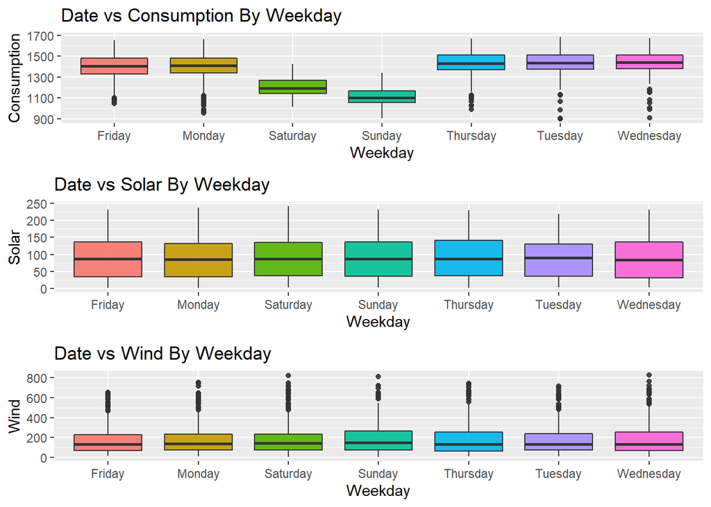

```r
# add new column and convert Date into weekdays
dat_2$Weekday <- weekdays(dat_2$Date)

### Plot data by months. Use the box plots to visualise the data vs month
pa1 <- ggplot(data=dat_2, mapping=aes(x=Weekday, y=Consumption, fill=Weekday)) + geom_boxplot(alpha=0.9) + theme(legend.position="none") + labs(title="Date vs Consumption By Weekday")

pa2 <- ggplot(data=dat_2, mapping=aes(x=Weekday, y=Solar, fill=Weekday)) + geom_boxplot(alpha=0.9)+ theme(legend.position="none") + labs(title="Date vs Solar By Weekday")

pa3 <- ggplot(data=dat_2, mapping=aes(x=Weekday, y=Wind, fill=Weekday)) + geom_boxplot(alpha=0.9) + theme(legend.position="none") + labs(title="Date vs Wind By Weekday")

ggarrange(pa1, pa2, pa3 , ncol = 1, nrow = 3) #labels = c("Consumption", "Wind", "Solar")
```

#### The above figure shows that electricity consumption is higher on weekdays than on weekends. Interestingly, there are more outliers on the weekdays.

## Plot Consumption vs Wind.Solar of 2016

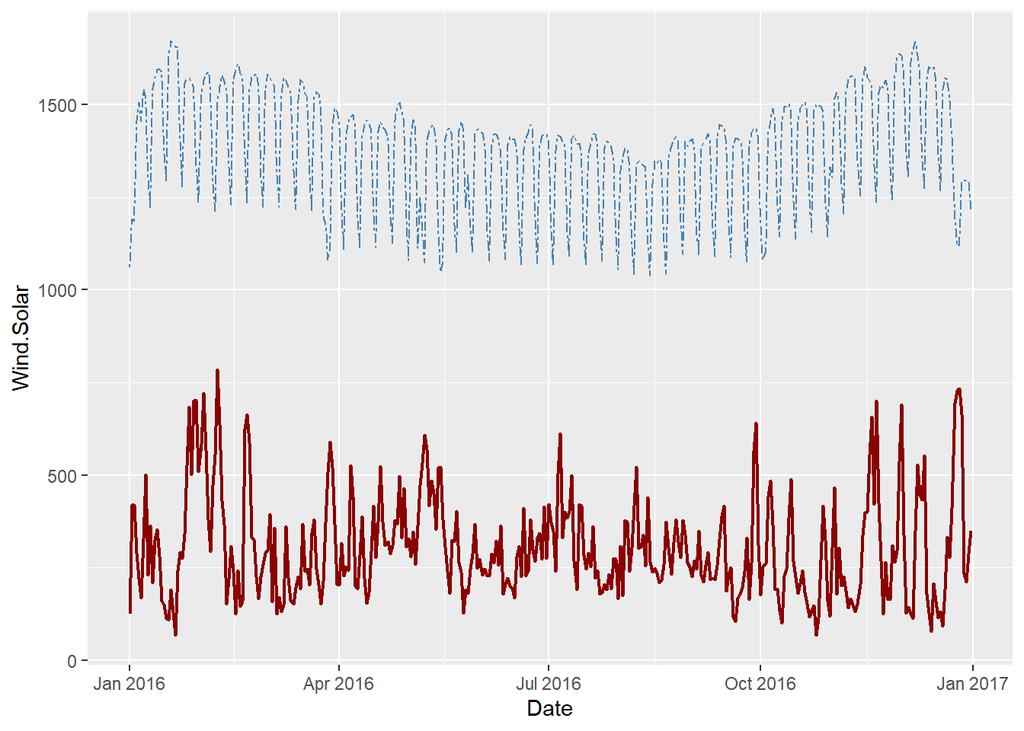

```r
# filter data for last week of December 2016
dy2 <- filter(dat_2, Year == 2016)
ggplot(dy2, aes(x=Date)) + geom_line(aes(y = Wind.Solar), color = "darkred", size=0.8) +
geom_line(aes(y = Consumption), color="steelblue", linetype="twodash")
```